# Supervised Learning with Prostate Cancer

## Final for Supervised Learning: Classification

#### 2021.07.13

# I. Introduction

Prostate health is a [serious and widespread concern](https://www.cancer.org/cancer/prostate-cancer/about/key-statistics.html) for men in the US. This data set explores some response variables from a sample [dataset](https://web.stanford.edu/~hastie/ElemStatLearn/data.html).

# II. Data

For my final project, I chose the prostate cancer data from [Datasets for "The Elements of Statistical Learning](https://web.stanford.edu/~hastie/ElemStatLearn/data.html).

## 1. Packages

```python
import math
import matplotlib.pyplot as plt
from matplotlib.ticker import StrMethodFormatter as SMF
import numpy as np
import pandas as pd
import seaborn as sns
from warnings import filterwarnings as fw
fw("ignore")
```

## 2. Read Data

Details can be found [here](http://search.r-project.org/library/ElemStatLearn/html/prostate.html).

```python
prostate = pd.read_table("https://web.stanford.edu/~hastie/ElemStatLearn/datasets/prostate.data", sep = "\t", index_col = 0)
prostate = prostate[['age', 'lbph', 'lcp',
                     'lcavol', 'lweight', 'pgg45',
                     'gleason', 'lpsa', 'svi']].rename(columns = {"age": "Age",
                                                                  "lbph": "logBPH",
                                                                  "lcp": "logCP",
                                                                  "lcavol": "logCV",
                                                                  "lweight": "logPW",
                                                                  "pgg45": "Gleason2",
                                                                  "gleason": "Gleason1",
                                                                  "lpsa": "logPSA",
                                                                  "svi": "SVI"})
prostate
```

|  | Age | logBPH | logCP | logCV | logPW | Gleason2 | Gleason1 | logPSA | SVI |
| --- | --- | --- | --- | --- | --- | --- | --- | --- | --- |
| 1 | 50 | -1.386294 | -1.386294 | -0.579818 | 2.769459 | 0 | 6 | -0.430783 | 0 |
| 2 | 58 | -1.386294 | -1.386294 | -0.994252 | 3.319626 | 0 | 6 | -0.162519 | 0 |
| 3 | 74 | -1.386294 | -1.386294 | -0.510826 | 2.691243 | 20 | 7 | -0.162519 | 0 |
| 4 | 58 | -1.386294 | -1.386294 | -1.203973 | 3.282789 | 0 | 6 | -0.162519 | 0 |
| 5 | 62 | -1.386294 | -1.386294 | 0.751416 | 3.432373 | 0 | 6 | 0.371564 | 0 |
| ... | ... | ... | ... | ... | ... | ... | ... | ... | ... |
| 93 | 68 | -1.386294 | 1.321756 | 2.830268 | 3.876396 | 60 | 7 | 4.385147 | 1 |
| 94 | 44 | -1.386294 | 2.169054 | 3.821004 | 3.896909 | 40 | 7 | 4.684443 | 1 |
| 95 | 52 | -1.386294 | 2.463853 | 2.907447 | 3.396185 | 10 | 7 | 5.143124 | 1 |
| 96 | 68 | 1.558145 | 1.558145 | 2.882564 | 3.773910 | 80 | 7 | 5.477509 | 1 |
| 97 | 68 | 0.438255 | 2.904165 | 3.471966 | 3.974998 | 20 | 7 | 5.582932 | 1 |

97 rows × 9 columns

## 3. Objective

The objective of this study is to predict various outcomes. Here are the questions that will be answered.

- Can *Gleason Score* be predicted from other variables?
- Can *Prostate-Specific Antigen* levels be predicted from other variables?
- Can *Seminal Vesicle Invasion* be predicted from other variables?

# III. Exploratory Data Analysis

There are no missing values and several variables have already been log transformed.

## 1. Distributions and Histograms

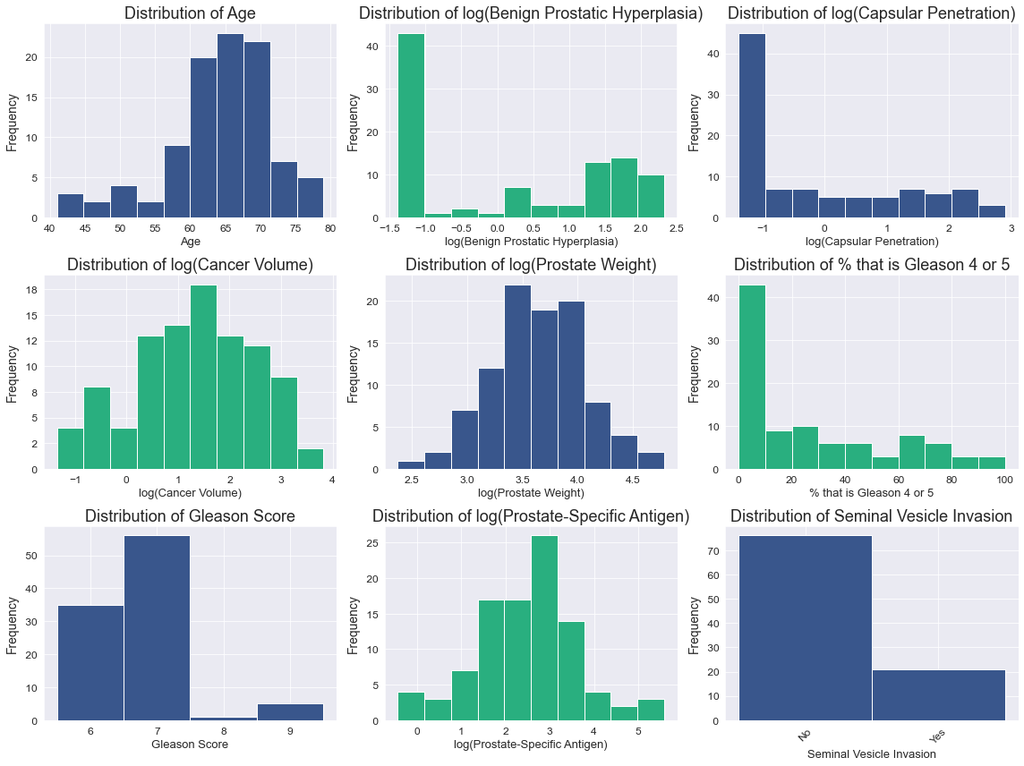

```python
sns.set_style('darkgrid')

def hist_helper(df, ax, var, name, b, c):
    ax.hist(df[var],
            bins = b,
            color = [c],
            stacked = True)
    ax.set_title("Distribution of " + name, fontsize = 18)
    ax.set_xlabel(xlabel = name, fontsize = 13)
    if (var == 'SVI'):
        plt.sca(ax)
        plt.xticks(ticks = [0.25, 0.75], labels = ['No', 'Yes'], ha = 'center', rotation = 45)
    elif (var == 'Gleason1'):
        plt.sca(ax)
        plt.xticks(ticks = [6.375, 7.125, 7.875, 8.625], labels = [6, 7, 8, 9])
    ax.set_ylabel(ylabel = "Frequency", fontsize = 14)
    ax.yaxis.set_major_formatter(SMF('{x: ,.0f}'))
    ax.tick_params(axis = 'both', labelsize = 12)

fig, ax = plt.subplots(3, 3, figsize = (16, 12))

c1 = '#39568CFF'
c2 = '#29AF7FFF'

hist_helper(prostate, ax[0][0], 'Age', 'Age', 10, c1)
hist_helper(prostate, ax[0][1], 'logBPH', 'log(Benign Prostatic Hyperplasia)', 10, c2)
hist_helper(prostate, ax[0][2], 'logCP', 'log(Capsular Penetration)', 10, c1)

hist_helper(prostate, ax[1][0], 'logCV', 'log(Cancer Volume)', 10, c2)
hist_helper(prostate, ax[1][1], 'logPW', 'log(Prostate Weight)', 10, c1)
hist_helper(prostate, ax[1][2], 'Gleason2', '% that is Gleason 4 or 5', 10, c2)


hist_helper(prostate, ax[2][0], 'Gleason1', 'Gleason Score', 4, c1)
hist_helper(prostate, ax[2][1], 'logPSA', 'log(Prostate-Specific Antigen)', 10, c2)
hist_helper(prostate, ax[2][2], 'SVI', 'Seminal Vesicle Invasion', 2, c1)

fig.tight_layout()
fig.savefig('Supervised1 - Histograms.png');
```

## 2. Skew

```python
float_columns = [x for x in prostate.columns if x not in ['Gleason1', 'SVI']]

prostate[float_columns].skew().sort_values()
```

```
Age        -0.828476
logCV      -0.250304
logPSA     -0.000434
logPW       0.063541
logBPH      0.133813
logCP       0.728634
Gleason2    0.968105
dtype: float64
```

`Age` is left skewed.

`logCV`, `logPSA`, and `logPW` have been appropriately log transformed and are close to normal distribution.

`logBPH`, `logCP`, and `Gleason2` all have over 40% of their observations in the least value bin.

`Gleason1` and `SVI` are both categorical and are unbalanced.

## 3. Correlation

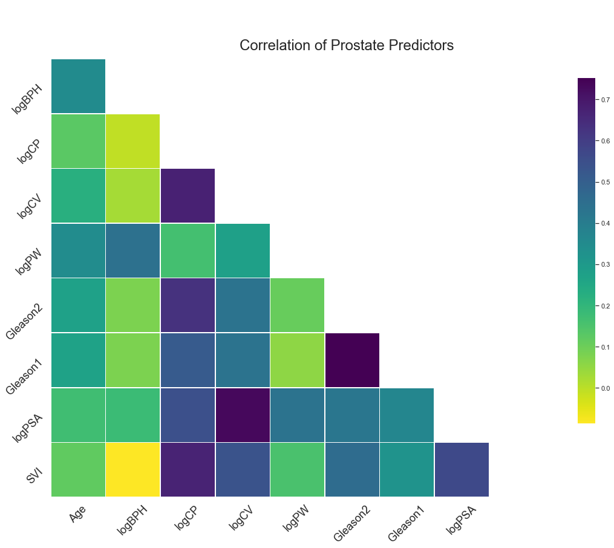

```python
#https://seaborn.pydata.org/examples/many_pairwise_correlations.html
sns.set_theme(style = "white")

# Compute the correlation matrix.
corr = prostate.corr()

#Maximum and minimum.
vmax = corr[corr < 1].max().max()
vmin = corr.min().min()

# Generate a mask for the upper triangle.
mask = np.triu(np.ones_like(corr, dtype = bool))

# Set up the matplotlib figure.
fig, ax = plt.subplots(figsize = (20, 15))

# Draw the heatmap with the mask and correct aspect ratio.
sns.heatmap(corr,
            mask = mask,
            cmap = 'viridis_r',
            vmax = vmax,
            vmin = vmin,
            square = True,
            linewidths = .5,
            cbar_kws = {"shrink": .7})

plt.title("Correlation of Prostate Predictors", x = .6, y = .9, fontsize = 24,)
xl, xt = plt.xticks()
plt.xticks(ticks = xl[0:-1],
           labels = xt[0:-1],
           fontsize = 18,
           ha = 'center',
           rotation = 45);

yl, yt = plt.yticks()
plt.yticks(ticks = yl[1:],
           labels = yt[1:],
           fontsize = 18,
           rotation = 45)

fig.savefig('Supervised2 - Correlations.png', bbox_inches = 'tight', pad_inches = 0.05);
```

`Gleason1` and `Gleason2` have the highest correlation at around 0.75.

`logCV` and `logPSA`, `logCP` and `logCV`, and `logCP` and `SVI` also have high correlations.

No variables will be removed, as multicollinearity is not an issue.

# IV. Classification Models

## 1. Outcome Variables.

When set as the outcome variable,

- *Gleason Score* will be classified as *6*, *7* or *8 or 9*
- *Prostate-Specific Antigen* is positively correlated with Prostate Cancer, however there is [no set cutoff](https://www.cancer.org/cancer/prostate-cancer/detection-diagnosis-staging/tests.html).
- *Seminal Vesicle Invasion* already has binary classification labels, so will remain unchanged

The chart below summarizes the corresponding labels created:

| Prostate-Specific Antigen (*ng/mL*) | log(PSA) | Output Classification Label |
| --- | --- | --- |
| $< 4$ | $< 1.3863$ | *Low Risk* |
| $4 - 10$ | $1.3863 - 2.3026$ | *Borderline Risk* |
| $> 10$ | $> 2.3026$ | *High Risk* |

```python
prostate['y_Gleason'] = prostate['Gleason1'].replace([6,7,8,9], [0,1,2,2])

def psa_risk(p):
    if (p < 1.3863) :
        v = 0
    elif (p > 2.3026) :
        v = 2
    else :
        v = 1
    return(v)

prostate['y_PSA'] = prostate['logPSA'].apply(lambda p: psa_risk(p))

prostate['y_SVI'] = prostate['SVI']
```

## 2. Train Test Split

The data will be split into training (70%) and test (30%) sets. Then for each of the 3 outcome variables, the appropriate variables will be kept as predictors and set as the outcome.

```python
from sklearn.model_selection import train_test_split as TTS
train, test = TTS(prostate, test_size = 0.3, random_state = 31313)

non_pred = ['Age', 'logBPH', 'logCP', 'logCV', 'logPW', 'Gleason2']

XG_train = train[non_pred + ['logPSA', 'SVI']]
XG_test = test[non_pred + ['logPSA', 'SVI']]
yG_train = train['y_Gleason'].values
yG_test = test['y_Gleason'].values

XP_train = train[non_pred + ['Gleason1', 'SVI']]
XP_test = test[non_pred + ['Gleason1', 'SVI']]
yP_train = train['y_PSA'].values
yP_test = test['y_PSA'].values

XS_train = train[non_pred + ['Gleason1', 'logPSA']]
XS_test = test[non_pred + ['Gleason1', 'logPSA']]
yS_train = train['y_SVI'].values
yS_test = test['y_SVI'].values
```

## 3. Models

I am using three supervised learning algorithms:

- Decision Tree (Random Forest)
- K-Nearest Neighbors
- Support Vector Machine (Polynomial of degree 3)

Each model will be run in a validation curve simulation to optimize its respective parameter/hyperparameter.

Data entered to KNN will always have been scaled beforehand.

In addition, each model will be run for all three training sets.

```python
from sklearn.model_selection import validation_curve as VC

#Graphs Validation Curve of Train and Validation Sets given a model, X, y, and name of model.
def model_vc(model, X, y, name, f):

    #Random Forest.
    if (name == "Random Forest"):
        param_name = "max_depth"
        param_range = list(range(2, 11))
        proper = "Maximum Depth"

    #K-Nearest Neighbor.
    elif name == "K-Nearest Neighbor":
        param_name = "n_neighbors"
        param_range = [n for n in range(1, 44)]
        proper = "# of Neighbors"

    #SVM.
    else:
        param_name = "C"
        param_range = [10**n for n in range(-5, 6)]
        proper = "C"

    #Validation Curve with 3-fold.
    train_scores, valid_scores = VC(model,
                                    X,
                                    y,
                                    param_name = param_name,
                                    param_range = param_range,
                                    cv = 3)

    #Get Accuracies.
    train_list = []
    valid_list = []
    for p in range(len(param_range)) :
        train_list.append(sum(train_scores[p]) / 3)
        valid_list.append(sum(valid_scores[p]) / 3)

    #Plot.
    fig, ax = plt.subplots(figsize = (10, 7))
    ax.plot(param_range, train_list, c = 'b', lw = 3, label = "Train Set")
    ax.plot(param_range, valid_list, c = 'g', lw = 3, label = "Validation Set")
    #Title.
    ax.set_title("Train and Validation Set Accuracies", fontsize = 22)

    #X-Axis.
    ax.set_xlabel(xlabel = proper, fontsize = 18)
    if (name == "Random Forest"):
        ax.set_xticks(param_range)
    elif (name == "K-Nearest Neighbor"):
        ax.set_xticks([5*x for x in range(10)])
    else:
        ax.set_xscale('log')
        proper = "Hyperparameter C Value"
    ax.set_xlabel(xlabel = proper, fontsize = 18)

    #Y-Axis.
    ax.set_ylabel(ylabel = "Accuracy", fontsize = 18)
    ax.yaxis.set_major_formatter(SMF('{x: 0.5f}'))
    ax.tick_params(axis = 'both', labelsize = 16)

    #Legend and Footnote.
    ax.legend(fontsize = 18, loc = 'center right')
    plt.figtext(0.9, 0, "3-fold cross-validation values were averaged.", ha = 'right', fontsize = 12)
    fig.savefig("Supervised" + f + ' - ' + name + '.png');
```

## 4. Decision Tree (Random Forest)

### i. Setup

```python
from sklearn.ensemble import RandomForestClassifier as RFC

model = RFC(n_estimators = 10,
            random_state = 31313)
```

### ii. Gleason Score

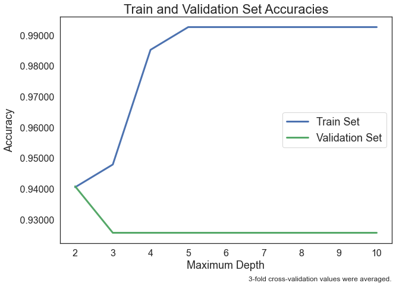

```python
model_vc(model, XG_train, yG_train, "Random Forest", '3')
```

A maximum depth of 2 will be used.

```python
dtrf_gs_model = RFC(n_estimators = 10,
                    max_depth = 2,
                    random_state = 31313).fit(XG_train, yG_train)
```

### iii. Prostate-Specific Antigen

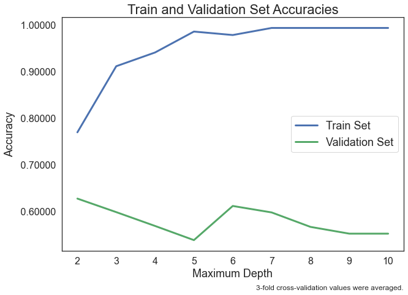

```python
model_vc(model, XP_train, yP_train, "Random Forest", '4')
```

A maximum depth of 6 will be used.

```python
dtrf_psa_model = RFC(n_estimators = 10,
                     max_depth = 6,
                     random_state = 31313).fit(XP_train, yP_train)
```

### iv. Seminal Vesicle Invasion

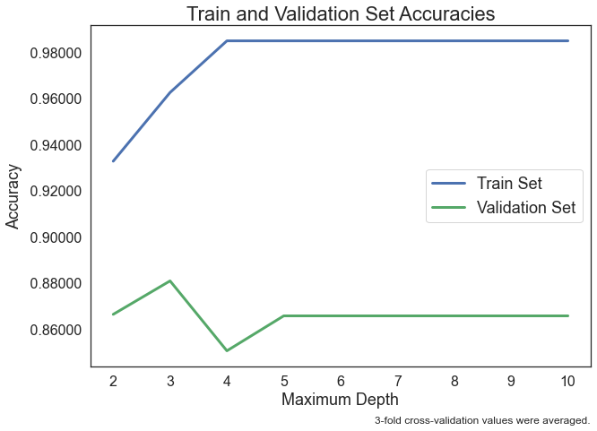

```python
model_vc(model, XS_train, yS_train, "Random Forest", '5')
```

A maximum depth of 3 will be used.

```python
dtrf_svi_model = RFC(n_estimators = 10,
                     max_depth = 3,
                     random_state = 31313).fit(XS_train, yS_train)
```

## 5. K-Nearest Neighbors

### i. Setup

```python
from sklearn.neighbors import KNeighborsClassifier as KNC
from sklearn.preprocessing import StandardScaler as SS

model = KNC()
```

### ii. Gleason Score

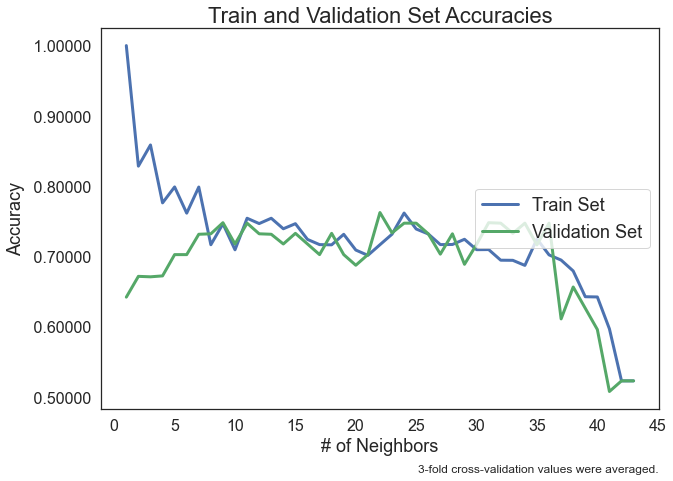

```python
model_vc(model, SS().fit_transform(XG_train), yG_train, "K-Nearest Neighbor", '6')
```

```python
knn_gs_model = KNC(n_neighbors = 11).fit(SS().fit_transform(XG_train), yG_train)
```

### iii. Prostate-Specific Antigen

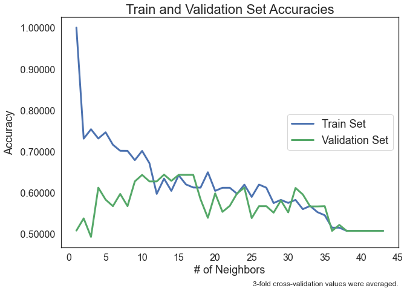

```python
model_vc(model, SS().fit_transform(XP_train), yP_train, "K-Nearest Neighbor", '7')
```

$N = 15$ will be used.

```python
knn_psa_model = KNC(n_neighbors = 15).fit(SS().fit_transform(XP_train), yP_train)
```

### iv. Seminal Vesicle Invasion

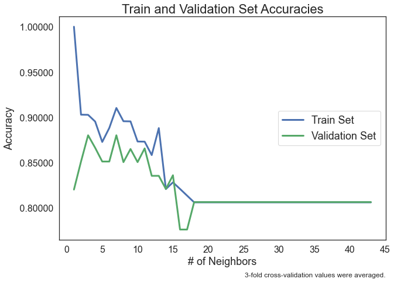

```python
model_vc(model, SS().fit_transform(XS_train), yS_train, "K-Nearest Neighbor", '8')
```

$N = 3$ will be used.

```python
knn_svi_model = KNC(n_neighbors = 3).fit(SS().fit_transform(XS_train), yS_train)
```

## 6. Support Vector Machine (Polynomial of degree 3)

### i. Setup

A support vector classifier with a polynomial of degree three kernal will be used. Hyperparameter $C$ values from $10^{−5}$ to $10^5$ will be evaluated to fit a final model.

```python
from sklearn.svm import SVC

model = SVC(kernel = 'poly', degree = 3)
```

### ii. Gleason Score

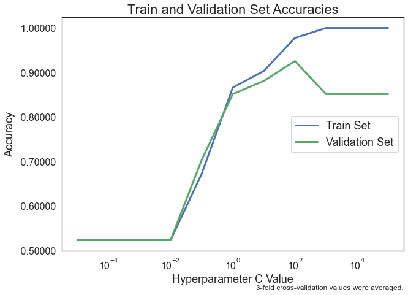

```python
model_vc(model, XG_train, yG_train, "SVM (Polynomial Degree 3)", '9')
```

$C = 10^{2}$ will be used.

```python
poly_gs_model = SVC(kernel = 'poly',
                    degree = 3,
                    C = 1e2).fit(XG_train, yG_train)
```

### iii. Prostate-Specific Antigen

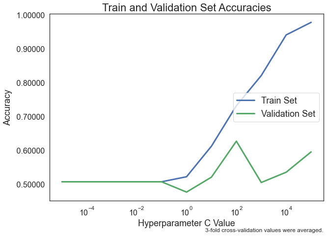

```python
model_vc(model, XP_train, yP_train, "SVM (Polynomial Degree 3)", '10')
```

$C = 10^{2}$ will be used.

```python
poly_psa_model = SVC(kernel = 'poly',
                     degree = 3,
                     C = 1e2).fit(XP_train, yP_train)
```

### iv. Seminal Vesicle Invasion

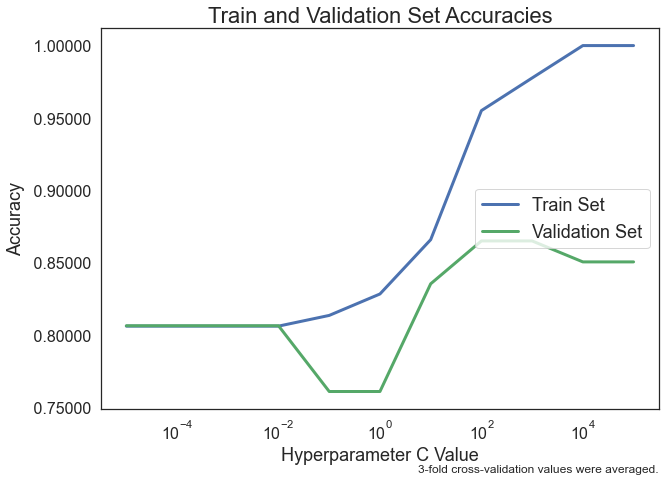

```python
model_vc(model, XS_train, yS_train, "SVM (Polynomial Degree 3)", '11')
```

$C = 10^{2}$ will be used.

```python
poly_svi_model = SVC(kernel = 'poly',
                     degree = 3,
                     C = 1e2).fit(XS_train, yS_train)
```

# IV. Results

## 1. Function

```python
from sklearn import metrics as m
from sklearn.metrics import accuracy_score as ac
from sklearn.metrics import precision_score as ps
from sklearn.metrics import recall_score as rs
from sklearn.metrics import f1_score as fs

#Returns the Jaccard and F1 score for the models.
def summary(Xys, models, outcome):
    accuracy = []
    precision = []
    recall = []
    f1s = []

    #Calculate scores from each model and append to lists.
    for m in range(3) :
        for Xy in Xys:
            X = Xy[0]
            if (m == 1):
                X = SS().fit_transform(X)

            y_pred = models[m].predict(X)
            accuracy.append(ac(Xy[1], y_pred))
            precision.append(ps(Xy[1], y_pred, average = 'weighted'))
            recall.append(rs(Xy[1], y_pred, average = 'weighted'))
            f1s.append(fs(Xy[1], y_pred, average = 'weighted'))

    #Names.
    dtrf = "Decision Tree/Random Forest"
    knn = "K-Nearest Neighbor"
    svm = "Support Vector Machine"
    train = ", Train Set"
    test = ", Test Set"

    #Output dataframe.
    data = {"Algorithm": [dtrf + train, dtrf + test,
                          knn + train, knn + test,
                          svm + train, svm + test],
            "Accuracy": accuracy,
            "Precision": precision,
            "Recall": recall,
            "F1-Score": f1s}

    report = pd.DataFrame(data = data).set_index("Algorithm")

    return(report.style.set_caption("Predicting " + outcome))
```

```python
summary([(XG_train, yG_train),
         (XG_test, yG_test)],
        [dtrf_gs_model, knn_gs_model, poly_gs_model],
        "Gleason Score")
```

Predicting Gleason Score

| Algorithm | Accuracy | Precision | Recall | F1-Score |
| --- | --- | --- | --- | --- |
| Decision Tree/Random Forest, Train Set | 0.940299 | 0.886720 | 0.940299 | 0.912061 |
| Decision Tree/Random Forest, Test Set | 0.933333 | 0.872464 | 0.933333 | 0.901515 |
| K-Nearest Neighbor, Train Set | 0.761194 | 0.723105 | 0.761194 | 0.735301 |
| K-Nearest Neighbor, Test Set | 0.666667 | 0.715556 | 0.666667 | 0.654040 |
| Support Vector Machine, Train Set | 0.970149 | 0.971763 | 0.970149 | 0.965589 |
| Support Vector Machine, Test Set | 0.966667 | 0.968182 | 0.966667 | 0.961499 |

```python
summary([(XP_train, yP_train),
         (XP_test, yP_test)],
        [dtrf_psa_model, knn_psa_model, poly_psa_model],
        "Prostate-Specific Antigen")
```

Predicting Prostate-Specific Antigen

| Algorithm | Accuracy | Precision | Recall | F1-Score |
| --- | --- | --- | --- | --- |
| Decision Tree/Random Forest, Train Set | 0.955224 | 0.956522 | 0.955224 | 0.955366 |
| Decision Tree/Random Forest, Test Set | 0.766667 | 0.772222 | 0.766667 | 0.767273 |
| K-Nearest Neighbor, Train Set | 0.716418 | 0.702927 | 0.716418 | 0.697149 |
| K-Nearest Neighbor, Test Set | 0.700000 | 0.764975 | 0.700000 | 0.720939 |
| Support Vector Machine, Train Set | 0.761194 | 0.765320 | 0.761194 | 0.761288 |
| Support Vector Machine, Test Set | 0.666667 | 0.754497 | 0.666667 | 0.696667 |

```python
summary([(XS_train, yS_train),
         (XS_test, yS_test)],
        [dtrf_svi_model, knn_svi_model, poly_svi_model],
        "Seminal Vesicle Invasion")
```

Predicting Seminal Vesicle Invasion

| Algorithm | Accuracy | Precision | Recall | F1-Score |
| --- | --- | --- | --- | --- |
| Decision Tree/Random Forest, Train Set | 0.970149 | 0.971215 | 0.970149 | 0.969177 |
| Decision Tree/Random Forest, Test Set | 0.833333 | 0.828157 | 0.833333 | 0.829630 |
| K-Nearest Neighbor, Train Set | 0.910448 | 0.917260 | 0.910448 | 0.912801 |
| K-Nearest Neighbor, Test Set | 0.900000 | 0.905820 | 0.900000 | 0.901778 |
| Support Vector Machine, Train Set | 0.925373 | 0.924038 | 0.925373 | 0.921515 |
| Support Vector Machine, Test Set | 0.833333 | 0.828157 | 0.833333 | 0.829630 |

# V. Confusion Matrices and Predictions

```python
from sklearn.metrics import plot_confusion_matrix as PCM
import matplotlib

def confusion(titles, outcome, models, Xs, ys, labels, f):

    data = ["Train Set", "Test Set"]
    titles = ["Random Forest (10 Trees, Maximum Depth = " + str(titles[0]) + ")",
              "K-Nearest Neighbors (N = " + str(titles[1]) + ")",
              "Support Vector Machine (Polynomial Kernel, Degree 3)"]

    fig, axes = plt.subplots(nrows = 3, ncols = 2, figsize = (15, 23))
    fig.suptitle(outcome, fontsize = 30, y = 0.92)
    plt.figtext(x = 0.5, y = 0.88, ha = 'center', s = titles[0], fontsize = 26)
    plt.figtext(x = 0.5, y = 0.62, ha = 'center', s = titles[1], fontsize = 26)
    plt.figtext(x = 0.5, y = 0.35, ha = 'center', s = titles[2], fontsize = 26)
    matplotlib.rcParams.update({'font.size': 30})

    for r in range(3):
        for c in range(2):
            ax = axes[r][c]

            X = Xs[c]
            if (r == 1):
                X = SS().fit_transform(X)

            PCM(estimator = models[r],
                X = X,
                y_true = ys[c],
                ax = ax,
                display_labels = labels,
                include_values = True)

            ax.set_title(data[c], fontsize = 20)
            ax.set_xlabel(xlabel = "Predicted Value", fontsize = 18)
            ax.set_ylabel(ylabel = "True Value", fontsize = 18)
            ax.tick_params(axis = 'both', labelsize = 16)
            ax.images[-1].colorbar.remove()
            ax.grid(False)

    fig.savefig("Supervised" + f + " Matrix.png");
```

[figure not shown]

```python
confusion(titles = (2, 7),
          outcome = "Gleason Score",
          models = [dtrf_gs_model, knn_gs_model, poly_gs_model],
          Xs = (XG_train, XG_test),
          ys = (yG_train, yG_test),
          labels = ["6", "7", "8 or 9"],
          f = "15 - Gleason")
```

[figure not shown]

```python
confusion(titles = (2, 10),
          outcome = "Risk Associated with Prostate-Specific Antigen",
          models = [dtrf_psa_model, knn_psa_model, poly_psa_model],
          Xs = (XP_train, XP_test),
          ys = (yP_train, yP_test),
          labels = ["Low", "Borderline", "High"],
          f = "16 - PSA")
```

| Prostate-Specific Antigen (*ng/mL*) | log(PSA) | Output Classification Label |
| --- | --- | --- |
| $< 4$ | $< 1.3863$ | *Low Risk* |
| $4 - 10$ | $1.3863 - 2.3026$ | *Borderline Risk* |
| $> 10$ | $> 2.3026$ | *High Risk* |

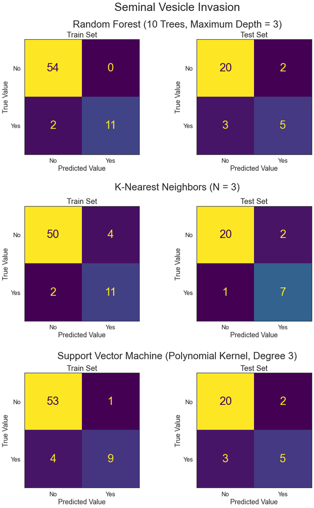

```python
confusion(titles = (3, 3),
          outcome = "Seminal Vesicle Invasion",
          models = [dtrf_svi_model, knn_svi_model, poly_svi_model],
          Xs = (XS_train, XS_test),
          ys = (yS_train, yS_test),
          labels = ["No", "Yes"],
          f = "17 - SVI")
```